LXG

Above and Beyond.

# 摘录分享：少即是多的性能优化

Xinguang Liu

January 23, 2017

## 序言

近日看了由Holger Schwender和Tina Müller写的[《Computing Thousands of Test Statistics Simultaneously in R》](http://stat-computing.org/newsletter/issues/scgn-18-1.pdf)介绍对高维数据进行各种检验，正好这个章节在`Advanced R`中也有引用到，反复读了几遍，感觉很好，摘录分享。

代码优化的问题其实应该当**哲学**问题来看待，优美的编码赏心悦目：

> less is more, or more is less, the question of how to do balance depends on what you plan to do. —-这是我此刻想说的.

## 主题1: 两样本比较

基因数据(54,675行,50列)，其中行数据为特征变量，列数据为50个人的观测值（注：这个数据跟通常的数据框行列含义不同），其中前25个人为第1组，后25个人为第2组。

```r
# 产生模拟数据
m <- 54675
n <- 50
X <- matrix(rnorm(m * n, mean = 10, sd = 3), nrow = m)
# 样本分为两组
cl <- rep(0:1, each = n/2)
# 用于存放结果变量
res0 <- numeric(m)  # 基准结果
res <- numeric(m)  # 新方法结果
```

### 方法1: 用`t.test`的公式接口

```r
time1 <- system.time({
    for (i in 1:m) {
        res0[i] <- t.test(X[i, ] ~ cl)$stat
    }
})
time1
```

```
#>    user  system elapsed
#>   66.83    0.02   67.19
```

### 方法2: 用`t.test`的向量输入接口

```r
time2 <- system.time({
    for (i in 1:m) {
        res[i] <- t.test(X[i, cl == 0], X[i, cl == 1])$stat
    }
})
stopifnot(all.equal(res0, res))
time2
```

```
#>    user  system elapsed
#>    12.2     0.0    12.2
```

### 方法3: `apply()`

```r
compT <- function(x, cl) {
    t.test(x[cl == 0], x[cl == 1])$stat
}
time3 <- system.time(res <- apply(X, 1, compT, cl = cl))
stopifnot(all.equal(res0, res))
time3
```

```
#>    user  system elapsed
#>   12.79    0.01   12.87
```

### 方法4: 简化`t.test()`操作

```r
rowtstat <- function(X, cl) {
    X0 <- X[cl == 0]
    X1 <- X[cl == 1]
    m0 <- mean(X0)
    m1 <- mean(X1)
    n0 <- sum(cl == 0)
    n1 <- sum(cl)
    sq <- function(x) x * x
    s0 <- sum(sq(X0 - m0))
    s0 <- s0/(n0 * (n0 - 1))
    s1 <- sum(sq(X1 - m1))
    s1 <- s1/(n1 * (n1 - 1))
    (m0 - m1)/sqrt(s0 + s1)
}
time4 <- system.time(res <- apply(X, 1, rowtstat, cl = cl))
stopifnot(all.equal(res0, res))
time4
```

```
#>    user  system elapsed
#>     1.7     0.0     1.7
```

### 方法5: 简化`t.test()`操作，使用向量化函数

```r
rowtstat2 <- function(X, cl) {
    X0 <- X[, cl == 0]
    X1 <- X[, cl == 1]
    m0 <- rowMeans(X0)
    m1 <- rowMeans(X1)
    n0 <- sum(cl == 0)
    n1 <- sum(cl)
    sq <- function(x) x * x
    s0 <- rowSums(sq(X0 - m0))
    s0 <- s0/(n0 * (n0 - 1))
    s1 <- rowSums(sq(X1 - m1))
    s1 <- s1/(n1 * (n1 - 1))
    (m0 - m1)/sqrt(s0 + s1)
}
time5 <- system.time(res <- rowtstat2(X, cl))
stopifnot(all.equal(res0, res))
time5
```

```
#>    user  system elapsed
#>    0.07    0.03    0.10
```

### 其它

文章中还引用了两个`Bioconductor`上的包函数进行比较，感兴趣的可以查看原文。

- `rowttests()` from `genefilter`;
- `mt.teststat()` from `multtest`.

### 耗时汇总

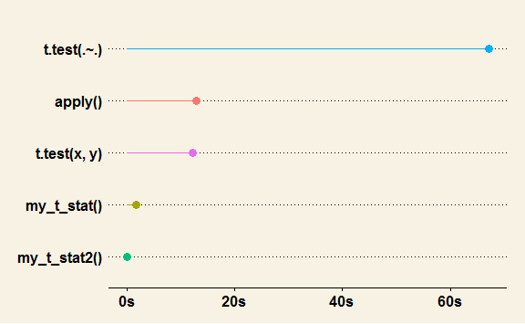

## 其它主题

- `Wilcoxon`秩检验
- 多组别`F`检验
- 多模型拟合
- 类别数据的`Chisq`检验

其中，除**多模型拟合**章节外，其它三部分主要介绍了三个包函数的引用，可以查看原文中的代码用例。

如何加速**多模型拟合**是个非常好的话题，除文章中的方法外，还有其它思路可以借鉴，留待下次更新。

## 计算环境

```r
devtools::session_info()[1]
```

```
#> $platform
#>  setting  value
#>  version  R version 3.3.2 (2016-10-31)
#>  system   x86_64, mingw32
#>  ui       RTerm
#>  language (EN)
#>  collate  Chinese (Simplified)_People's Republic of China.936
#>  tz       Asia/Taipei
#>  date     2017-01-23
```